# Regional association, Manhattan, and QQ plotting for age of ischemic stroke onset.

### Men-only analyses

```r
library(RACER)
# Make directory for plots
ifelse(!dir.exists(file.path(PROJECT_loc, "/RACER")),
       dir.create(file.path(PROJECT_loc, "/RACER")),
       FALSE)
```

```
[1] FALSE
```

```
Getting data for rs6051656.

Subset required data.

Formatting association data.
```

```
Formating association data...
Processing -log10(p-values)...
Preparing association data...
```

```
Getting LD data.
```

```
All inputs are go!
Reading in association data...
Populations selected.
Calculating LD using rs6051656...
```

```
[1] "https://ldlink.nci.nih.gov/LDlinkRest/ldproxy?var=rs6051656&pop=EUR&r2_d=r2&token=c0f613f149ab"
```

```
 [100%] Downloaded 14709 bytes...
Merging input association data with LD...
```

```
Plotting region surrounding rs6051656 on 20:124763-624763.
```

```
Plotting by...
coord
Reading in association data
Determining lead SNP
Generating Plot
```

```
Saving image for rs6051656.
```

```
Getting data for rs429358.

Subset required data.

Formatting association data.
```

```
Formating association data...
Processing -log10(p-values)...
Preparing association data...
```

```
Getting LD data.
```

```
All inputs are go!
Reading in association data...
Populations selected.
Calculating LD using rs429358...
```

```
[1] "https://ldlink.nci.nih.gov/LDlinkRest/ldproxy?var=rs429358&pop=EUR&r2_d=r2&token=c0f613f149ab"
```

```
 [100%] Downloaded 29308 bytes...
Merging input association data with LD...
```

```
Plotting region surrounding rs429358 on 19:45161941-45661941.
```

```
Plotting by...
coord
Reading in association data
Determining lead SNP
Generating Plot
```

```
Saving image for rs429358.
```

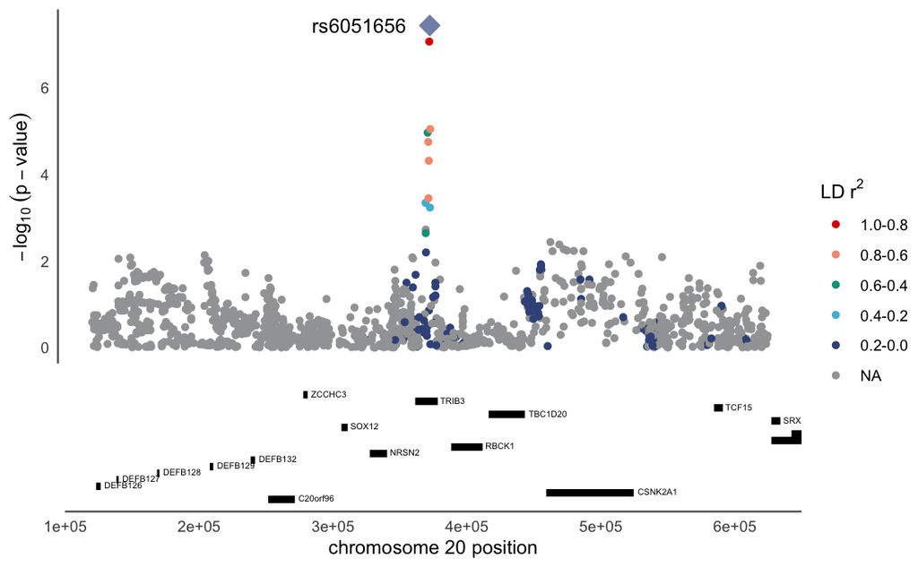

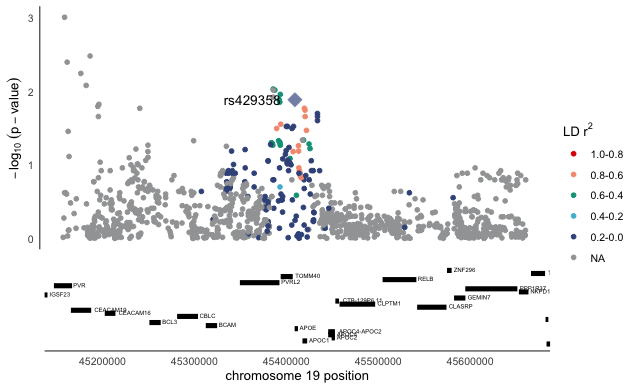

```r
RACER_loc = paste0(PROJECT_loc,"/RACER")

variants_of_interest <- c(variant_list$rsID)
# variants_of_interest_test <- "rs6051656"

for(VARIANT in variants_of_interest){
  cat(paste0("Getting data for ", VARIANT,".\n"))

  tempCHR <- subset(variant_list, rsID == VARIANT)[,2]
  tempSTART <- subset(variant_list, rsID == VARIANT)[,3] - RANGE
  tempEND <- subset(variant_list, rsID == VARIANT)[,3] + RANGE
  tempVARIANTnr <- subset(variant_list, rsID == VARIANT)[,1]
  tempLOCUS <- subset(variant_list, rsID == VARIANT)[,4]

  cat("\nSubset required data.\n")
  temp <- subset(gwas_sumstats_racer_XY, CHR == tempCHR & (BP >= tempSTART & BP <= tempEND))

  cat("\nFormatting association data.\n")
  temp_f = RACER::formatRACER(assoc_data = temp, chr_col = 2, pos_col = 3, p_col = 4)

  cat("\nGetting LD data.\n")
  temp_f_ld = RACER::ldRACER(assoc_data = temp_f, rs_col = 1, pops = "EUR", lead_snp = VARIANT)

  cat(paste0("\nPlotting region surrounding ", VARIANT," on ",tempCHR,":",tempSTART,"-",tempEND,".\n"))
  # source(paste0(PROJECT_loc, "/scripts/functions.R"))
  p2 <- singlePlotRACER2(assoc_data = temp_f_ld,
                        chr = tempCHR, build = "hg19",
                        plotby = "coord", start_plot = tempSTART, end_plot = tempEND,
                        snp_plot = VARIANT,
                        label_lead = TRUE, gene_track_h = 2, gene_name_s = 1.75)

  print(p2)
  cat(paste0("Saving image for ", VARIANT,".\n"))
  ggsave(filename = paste0(RACER_loc, "/", Today, ".", tempVARIANTnr, ".", tempLOCUS,".regional_assoc.XY.png"), plot = p2)
  ggsave(filename = paste0(RACER_loc, "/", Today, ".", tempVARIANTnr, ".", tempLOCUS,".regional_assoc.XY.pdf"), plot = p2)
  ggsave(filename = paste0(RACER_loc, "/", Today, ".", tempVARIANTnr, ".", tempLOCUS,".regional_assoc.XY.eps"), plot = p2)

  rm(temp, p2,
     temp_f, temp_f_ld,
     tempCHR, tempSTART, tempEND,
     VARIANT, tempVARIANTnr, tempLOCUS)

}
```

### Women-only analyses

```r
library(RACER)
# Make directory for plots
ifelse(!dir.exists(file.path(PROJECT_loc, "/RACER")),
       dir.create(file.path(PROJECT_loc, "/RACER")),
       FALSE)
```

```
[1] FALSE
```

```
Getting data for rs6051656.

Subset required data.

Formatting association data.
```

```
Formating association data...
Processing -log10(p-values)...
Preparing association data...
```

```
Getting LD data.
```

```
All inputs are go!
Reading in association data...
Populations selected.
Calculating LD using rs6051656...
```

```
[1] "https://ldlink.nci.nih.gov/LDlinkRest/ldproxy?var=rs6051656&pop=EUR&r2_d=r2&token=c0f613f149ab"
```

```
 [100%] Downloaded 14709 bytes...
Merging input association data with LD...
```

```
Plotting region surrounding rs6051656 on 20:124763-624763.
```

```
Plotting by...
coord
Reading in association data
Determining lead SNP
Generating Plot
```

```
Saving image for rs6051656.
```

```
Getting data for rs429358.

Subset required data.

Formatting association data.
```

```
Formating association data...
Processing -log10(p-values)...
Preparing association data...
```

```
Getting LD data.
```

```
All inputs are go!
Reading in association data...
Populations selected.
Calculating LD using rs429358...
```

```
[1] "https://ldlink.nci.nih.gov/LDlinkRest/ldproxy?var=rs429358&pop=EUR&r2_d=r2&token=c0f613f149ab"
```

```
 [100%] Downloaded 29308 bytes...
Merging input association data with LD...
```

```
Plotting region surrounding rs429358 on 19:45161941-45661941.
```

```
Plotting by...
coord
Reading in association data
Determining lead SNP
Generating Plot
```

```
Saving image for rs429358.
```

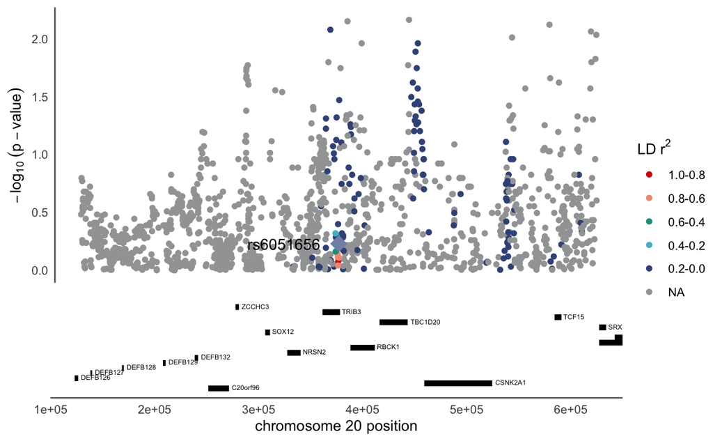

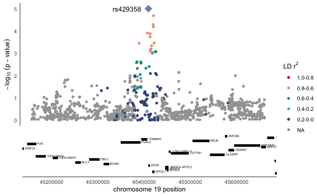

```r
RACER_loc = paste0(PROJECT_loc,"/RACER")

variants_of_interest <- c(variant_list$rsID)

for(VARIANT in variants_of_interest){
  cat(paste0("Getting data for ", VARIANT,".\n"))

  tempCHR <- subset(variant_list, rsID == VARIANT)[,2]
  tempSTART <- subset(variant_list, rsID == VARIANT)[,3] - RANGE
  tempEND <- subset(variant_list, rsID == VARIANT)[,3] + RANGE
  tempVARIANTnr <- subset(variant_list, rsID == VARIANT)[,1]
  tempLOCUS <- subset(variant_list, rsID == VARIANT)[,4]

  cat("\nSubset required data.\n")
  temp <- subset(gwas_sumstats_racer_XX, CHR == tempCHR & (BP >= tempSTART & BP <= tempEND))

  cat("\nFormatting association data.\n")
  temp_f = RACER::formatRACER(assoc_data = temp, chr_col = 2, pos_col = 3, p_col = 4)

  cat("\nGetting LD data.\n")
  temp_f_ld = RACER::ldRACER(assoc_data = temp_f, rs_col = 1, pops = "EUR", lead_snp = VARIANT)

  cat(paste0("\nPlotting region surrounding ", VARIANT," on ",tempCHR,":",tempSTART,"-",tempEND,".\n"))
  # source(paste0(PROJECT_loc, "/scripts/functions.R"))
  p3 <- singlePlotRACER2(assoc_data = temp_f_ld,
                        chr = tempCHR, build = "hg19",
                        plotby = "coord", start_plot = tempSTART, end_plot = tempEND,
                        snp_plot = VARIANT,
                        label_lead = TRUE, gene_track_h = 2, gene_name_s = 1.75)

  print(p3)
  cat(paste0("Saving image for ", VARIANT,".\n"))
  ggsave(filename = paste0(RACER_loc, "/", Today, ".", tempVARIANTnr, ".", tempLOCUS,".regional_assoc.XX.png"), plot = p3)
  ggsave(filename = paste0(RACER_loc, "/", Today, ".", tempVARIANTnr, ".", tempLOCUS,".regional_assoc.XX.pdf"), plot = p3)
  ggsave(filename = paste0(RACER_loc, "/", Today, ".", tempVARIANTnr, ".", tempLOCUS,".regional_assoc.XX.eps"), plot = p3)

  rm(temp, p3,
     temp_f, temp_f_ld,
     tempCHR, tempSTART, tempEND,
     VARIANT, tempVARIANTnr, tempLOCUS)

}
```

### Comparing the sexes

We can compare, visually, the men-only and women-only results.

```r
library(RACER)
# Make directory for plots
ifelse(!dir.exists(file.path(PLOT_loc, "/RACER")),
       dir.create(file.path(PLOT_loc, "/RACER")),
       FALSE)
```

```
[1] FALSE
```

```
Getting data for rs6051656.

Subset required data.

Formatting association data.
```

```
Formating association data...
Processing -log10(p-values)...
Preparing association data...
Formating association data...
Processing -log10(p-values)...
Preparing association data...
```

```
Getting LD data.
```

```
All inputs are go!
Reading in association data...
Populations selected.
Calculating LD using rs6051656...
```

```
[1] "https://ldlink.nci.nih.gov/LDlinkRest/ldproxy?var=rs6051656&pop=EUR&r2_d=r2&token=c0f613f149ab"
```

```
 [100%] Downloaded 14709 bytes...
Merging input association data with LD...
All inputs are go!
Reading in association data...
Populations selected.
Calculating LD using rs6051656...
```

```
[1] "https://ldlink.nci.nih.gov/LDlinkRest/ldproxy?var=rs6051656&pop=EUR&r2_d=r2&token=c0f613f149ab"
```

```
Merging input association data with LD...
```

```
Plotting region surrounding rs6051656 on 20:274763-474763.
```

```
Plotting by...
coord
Reading in association data
Generating plot.
Reading in association data
Generating plot.
```

```
Saving images for rs6051656.
```

```
Getting data for rs429358.

Subset required data.

Formatting association data.
```

```
Formating association data...
Processing -log10(p-values)...
Preparing association data...
Formating association data...
Processing -log10(p-values)...
Preparing association data...
```

```
Getting LD data.
```

```
All inputs are go!
Reading in association data...
Populations selected.
Calculating LD using rs429358...
```

```
[1] "https://ldlink.nci.nih.gov/LDlinkRest/ldproxy?var=rs429358&pop=EUR&r2_d=r2&token=c0f613f149ab"
```

```
 [54%] Downloaded 15980 bytes...
 [100%] Downloaded 29308 bytes...
Merging input association data with LD...
All inputs are go!
Reading in association data...
Populations selected.
Calculating LD using rs429358...
```

```
[1] "https://ldlink.nci.nih.gov/LDlinkRest/ldproxy?var=rs429358&pop=EUR&r2_d=r2&token=c0f613f149ab"
```

```
Merging input association data with LD...
```

```
Plotting region surrounding rs429358 on 19:45311941-45511941.
```

```
Plotting by...
coord
Reading in association data
Generating plot.
Reading in association data
Generating plot.
```

```
Saving images for rs429358.
```

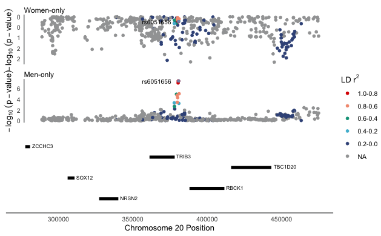

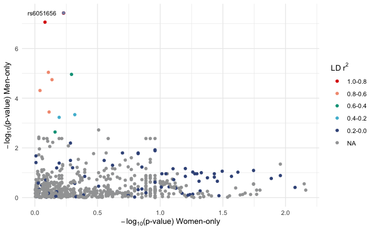

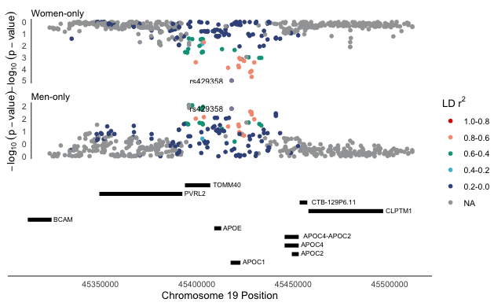

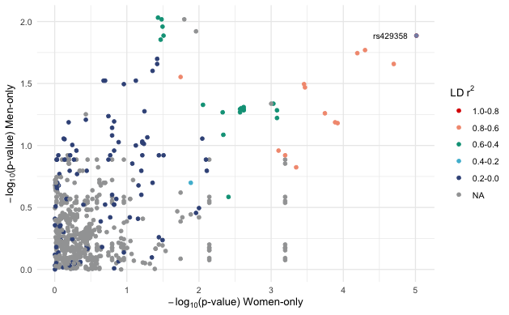

```r
RACER_loc = paste0(PLOT_loc,"/RACER")

RANGE=100000
variants_of_interest <- c(variant_list$rsID)

for(VARIANT in variants_of_interest){
  cat(paste0("Getting data for ", VARIANT,".\n"))

  tempCHR <- subset(variant_list, rsID == VARIANT)[,2]
  tempSTART <- subset(variant_list, rsID == VARIANT)[,3] - RANGE
  tempEND <- subset(variant_list, rsID == VARIANT)[,3] + RANGE
  tempVARIANTnr <- subset(variant_list, rsID == VARIANT)[,1]
  tempLOCUS <- subset(variant_list, rsID == VARIANT)[,4]

  cat("\nSubset required data.\n")
  temp_XX <- subset(gwas_sumstats_racer_XX, CHR == tempCHR & (BP >= tempSTART & BP <= tempEND))
  temp_XY <- subset(gwas_sumstats_racer_XY, CHR == tempCHR & (BP >= tempSTART & BP <= tempEND))

  cat("\nFormatting association data.\n")
  temp_f_XX = RACER::formatRACER(assoc_data = temp_XX, chr_col = 2, pos_col = 3, p_col = 4)
  temp_f_XY = RACER::formatRACER(assoc_data = temp_XY, chr_col = 2, pos_col = 3, p_col = 4)

  cat("\nGetting LD data.\n")
  temp_f_ld_XX = RACER::ldRACER(assoc_data = temp_f_XX, rs_col = 1, pops = "EUR", lead_snp = VARIANT)
  temp_f_ld_XY = RACER::ldRACER(assoc_data = temp_f_XY, rs_col = 1, pops = "EUR", lead_snp = VARIANT)

  cat(paste0("\nPlotting region surrounding ", VARIANT," on ",tempCHR,":",tempSTART,"-",tempEND,".\n"))
  # source(paste0(PROJECT_loc, "/scripts/functions.R"))
  p_mirror1 <- mirrorPlotRACER2(assoc_data1 = temp_f_ld_XX,
                                assoc_data2 = temp_f_ld_XY,
                                name1 = "Women-only",
                                name2 = "Men-only",
                                chr = tempCHR, plotby = "coord", start_plot = tempSTART, end_plot = tempEND,
                                snp_plot = VARIANT,
                                label_lead = TRUE, gene_track_h = 5)

  p_scatter1 <- scatterPlotRACER2(assoc_data1 = temp_f_ld_XX,
                                  assoc_data2 = temp_f_ld_XY,
                                  chr = tempCHR,
                                  name1 = "Women-only",
                                  name2 = "Men-only",
                                  region_start = tempSTART,
                                  region_end = tempEND, ld_df = 1, label = TRUE)
  print(p_mirror1)
  print(p_scatter1)
  cat(paste0("Saving images for ", VARIANT,".\n"))
  ggsave(filename = paste0(RACER_loc, "/", Today, ".", tempVARIANTnr, ".", tempLOCUS,".mirror.regional_assoc.XXvsXY.png"), plot = p_mirror1)
  ggsave(filename = paste0(RACER_loc, "/", Today, ".", tempVARIANTnr, ".", tempLOCUS,".mirror.regional_assoc.XXvsXY.pdf"), plot = p_mirror1)
  ggsave(filename = paste0(RACER_loc, "/", Today, ".", tempVARIANTnr, ".", tempLOCUS,".mirror.regional_assoc.XXvsXY.eps"), plot = p_mirror1)

  ggsave(filename = paste0(RACER_loc, "/", Today, ".", tempVARIANTnr, ".", tempLOCUS,".scatter.regional_assoc.XXvsXY.png"), plot = p_scatter1)
  ggsave(filename = paste0(RACER_loc, "/", Today, ".", tempVARIANTnr, ".", tempLOCUS,".scatter.regional_assoc.XXvsXY.pdf"), plot = p_scatter1)
  ggsave(filename = paste0(RACER_loc, "/", Today, ".", tempVARIANTnr, ".", tempLOCUS,".scatter.regional_assoc.XXvsXY.eps"), plot = p_scatter1)

  rm(temp_XX, temp_XY,
     temp_f_XX, temp_f_XY,
     temp_f_ld_XX,temp_f_ld_XY)
  rm(tempCHR, tempSTART, tempEND,
     p_mirror1, p_scatter1,
     VARIANT, tempVARIANTnr, tempLOCUS)

}
```

### Colocalisation of sex-stratified signals

We can also formally test the overlap between men and women.

```r
library(coloc)
gwas_sumstats_XY <- readRDS(file = paste0(OUT_loc, "/gwas_sumstats.xy.eur.groupcov.rds"))

gwas_sumstats_XX <- readRDS(file = paste0(OUT_loc, "/gwas_sumstats.xx.eur.groupcov.rds"))
```

```
Getting data for rs6051656.

Subset required data.

Calculate variance from beta.

Create minimum dataset for women-only.

Inspect the data for women-only.
```

```
Create minimum dataset for men-only.

Inspect the data for women-only.
```

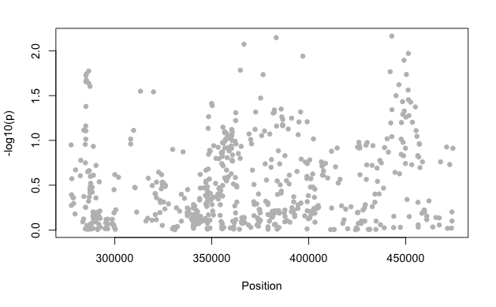

```
Finemap: formally test the colocalisation of the signal between women- and men-only analyses for rs6051656 at TRIB3.
```

```
PP.H0.abf PP.H1.abf PP.H2.abf PP.H3.abf PP.H4.abf
  0.87500   0.05140   0.06350   0.00373   0.00631
[1] "PP abf for shared variant: 0.631%"

Posterior probabilities.
```

```
Coloc analysis of trait 1, trait 2

SNP Priors
```

```
   p1    p2   p12
1e-04 1e-04 1e-05
```

```
Hypothesis Priors
```

```
        H0     H1     H2         H3      H4
 0.8752849 0.0578 0.0578 0.00333506 0.00578
```

```
Posterior
```

```
       nsnps           H0           H1           H2           H3           H4
5.780000e+02 8.750351e-01 5.142333e-02 6.350725e-02 3.725832e-03 6.308477e-03

Top results, if any.
Getting data for rs429358.

Subset required data.

Calculate variance from beta.

Create minimum dataset for women-only.

Inspect the data for women-only.
```

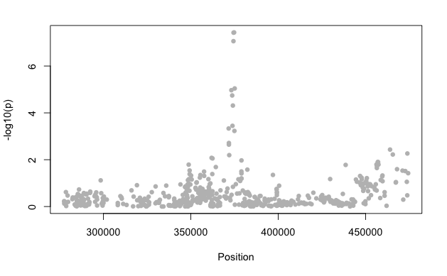

```
Create minimum dataset for men-only.

Inspect the data for women-only.
```

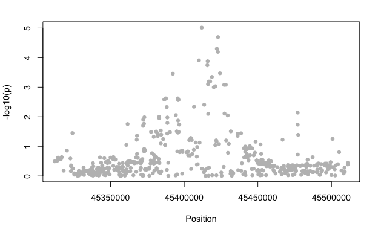

```
Finemap: formally test the colocalisation of the signal between women- and men-only analyses for rs429358 at APOE.
```

```
PP.H0.abf PP.H1.abf PP.H2.abf PP.H3.abf PP.H4.abf
  0.88600   0.05610   0.04850   0.00306   0.00587
[1] "PP abf for shared variant: 0.587%"

Posterior probabilities.
```

```
Coloc analysis of trait 1, trait 2

SNP Priors
```

```
   p1    p2   p12
1e-04 1e-04 1e-05
```

```
Hypothesis Priors
```

```
        H0     H1     H2         H3      H4
 0.8783847 0.0564 0.0564 0.00317532 0.00564
```

```
Posterior
```

```
       nsnps           H0           H1           H2           H3           H4
5.640000e+02 8.864961e-01 5.609692e-02 4.847527e-02 3.061615e-03 5.870088e-03

Top results, if any.
```

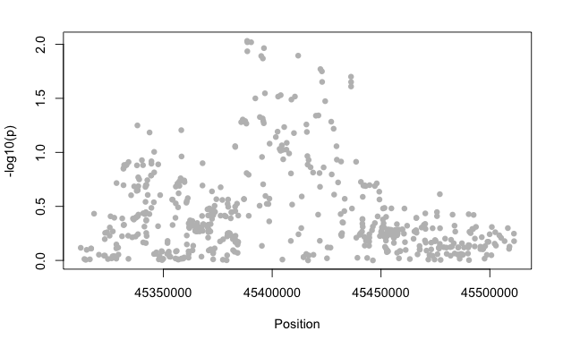

```r
RANGE=100000
variants_of_interest <- c(variant_list$rsID)

for(VARIANT in variants_of_interest){
  cat(paste0("Getting data for ", VARIANT,".\n"))

  tempCHR <- subset(variant_list, rsID == VARIANT)[,2]
  tempSTART <- subset(variant_list, rsID == VARIANT)[,3] - RANGE
  tempEND <- subset(variant_list, rsID == VARIANT)[,3] + RANGE
  tempVARIANTnr <- subset(variant_list, rsID == VARIANT)[,1]
  tempLOCUS <- subset(variant_list, rsID == VARIANT)[,4]

  cat("\nSubset required data.\n")
  temp_XX <- subset(gwas_sumstats_XX, CHR == tempCHR & (BP >= tempSTART & BP <= tempEND) & SNP != "-9")
  temp_XY <- subset(gwas_sumstats_XY, CHR == tempCHR & (BP >= tempSTART & BP <= tempEND) & SNP != "-9")

  # Ref: https://chr1swallace.github.io/coloc/articles/a02_data.html
  # var(beta) is the standard error of beta, squared

  cat("\nCalculate variance from beta.\n")
  temp_XX$varBETA <- temp_XX$SE^2
  temp_XY$varBETA <- temp_XY$SE^2

  cat("\nCreate minimum dataset for women-only.\n")
  minimum_ccdata_XX = list(
    c(temp_XX$BETA),
    c(temp_XX$varBETA),
    c(temp_XX$SNP),
    c(temp_XX$BP)
  )
  names(minimum_ccdata_XX) <- c("beta", "varbeta", "snp", "position")
  minimum_ccdata_XX$type = "cc"

  attr(minimum_ccdata_XX$beta, "names") <- temp_XX$SNP
  attr(minimum_ccdata_XX$varbeta, "names") <- temp_XX$SNP

  # str(minimum_ccdata_XX)

  cat("\nInspect the data for women-only.\n")
  coloc::plot_dataset(minimum_ccdata_XX)
  coloc::check_dataset(minimum_ccdata_XX)

  cat("\nCreate minimum dataset for men-only.\n")
  minimum_ccdata_XY = list(
    c(temp_XY$BETA),
    c(temp_XY$varBETA),
    c(temp_XY$SNP),
    c(temp_XY$BP)
  )
  names(minimum_ccdata_XY) <- c("beta", "varbeta", "snp", "position")
  minimum_ccdata_XY$type = "cc"

  attr(minimum_ccdata_XY$beta, "names") <- temp_XY$SNP
  attr(minimum_ccdata_XY$varbeta, "names") <- temp_XY$SNP

  # str(minimum_ccdata_XY)
  cat("\nInspect the data for women-only.\n")
  coloc::plot_dataset(minimum_ccdata_XY)
  coloc::check_dataset(minimum_ccdata_XY)

  cat(paste0("\nFinemap: formally test the colocalisation of the signal between women- and men-only analyses for ",tempVARIANTnr," at ",tempLOCUS,".\n"))
  # Ref https://chr1swallace.github.io/coloc/articles/a03_enumeration.html
  res_XX <- finemap.abf(dataset = minimum_ccdata_XX)
  res_XY <- finemap.abf(dataset = minimum_ccdata_XY)
  tail(res_XX,3)
  tail(res_XY,3)

  res.XXvsXY <- coloc.abf(dataset1 = minimum_ccdata_XX,
                          dataset2 = minimum_ccdata_XY)

  cat("\nPosterior probabilities.\n")
  print(res.XXvsXY)
  library(tidyverse)
  res.XXvsXY %>% write_lines(paste0(OUT_loc, "/",tempVARIANTnr,".",tempLOCUS,".coloc.res.XXvsXY.txt"))

  cat("\nTop results, if any.\n")
  subset(res.XXvsXY$results, SNP.PP.H4>0.01)


  o <- order(res.XXvsXY$results$SNP.PP.H4, decreasing = TRUE)
  cs <- cumsum(res.XXvsXY$results$SNP.PP.H4[o])
  w <- which(cs > 0.95)[1]
  res.XXvsXY$results[o,][1:w,]$snp

  rm(o, cs, w,
     res.XXvsXY,
     minimum_ccdata_XX,
     minimum_ccdata_XY)

  rm(tempCHR, tempSTART, tempEND,
     VARIANT, tempVARIANTnr, tempLOCUS)

  rm(temp_XX, temp_XY)

  }
```

# Manhattan and QQ plotting

```r
library(CMplot)
```

We rename the columns for p-values.

```r
colnames(gwas_sumstats_racer_ALL)[which(names(gwas_sumstats_racer_ALL) == "P_BOLT_LMM_INF")] <- "Sex-combined"
colnames(gwas_sumstats_racer_XY)[which(names(gwas_sumstats_racer_XY) == "P_BOLT_LMM_INF")] <- "Men-only"
colnames(gwas_sumstats_racer_XX)[which(names(gwas_sumstats_racer_XX) == "P_BOLT_LMM_INF")] <- "Women-only"
```

We merge the data for plotting.

```r
temp <- gwas_sumstats_racer_ALL %>% filter(SNP != "-9")

temp2 <- merge(temp,
               subset(gwas_sumstats_racer_XY, SNP != "-9" || `Sex-combined` > 0, select = c("SNP", "Men-only")),
               by.x = "SNP", by.y = "SNP",
               all.x = TRUE,
               sort = FALSE)

gwas_sumstats_racer_combo <- merge(temp2,
                                   subset(gwas_sumstats_racer_XX, SNP != "-9" || `Sex-combined` > 0, select = c("SNP", "Women-only")),
                                   by.x = "SNP", by.y = "SNP",
                                   all.x = TRUE,
                                   sort = FALSE)
rm(temp, temp2)

# str(gwas_sumstats_racer_combo)
# Classes ‘data.table’ and 'data.frame':    6620618 obs. of  6 variables:
#  $ SNP         : chr  "rs58108140" "rs180734498" "rs140337953" "rs116400033" ...
#  $ CHR         : int  1 1 1 1 1 1 1 1 1 1 ...
#  $ BP          : int  10583 13302 30923 51479 54490 54676 55299 58814 59040 61987 ...
#  $ Sex-combined: num  0.12 0.78 0.43 0.6 0.93 0.51 0.059 0.053 0.085 0.86 ...
#  $ Men-only    : num  0.34 0.68 1 0.59 0.45 0.32 0.11 0.049 0.058 0.73 ...
#  $ Women-only  : num  0.21 0.41 0.22 0.77 0.61 1 0.32 0.43 0.67 0.49 ...
#  - attr(*, ".internal.selfref")=<externalptr>
```

This results in a dataset with 6,620,618 variants with an rsID, instead of 6,750,510.

We also create a set with fewer SNPs, excluding those with p > 0.05, as this will speed up the (Manhattan) plotting.

```r
gwas_sumstats_racer_combo_sub <- gwas_sumstats_racer_combo %>% filter(`Sex-combined` < 0.05)
```

List the SNPs of interest.

- *TRIB3* locus, clumped using PLINK
- *APOE* locus, all variants in LD (r<sup>2</sup> >= 0.1) with rs429358 using SNiPA (b37)

```r
trib3_clump <- read.xlsx(paste0(TARGET_loc, "/targets.xlsx"), sheet = "Clump_TRIB3")
apoe_clump <- read.xlsx(paste0(TARGET_loc, "/targets.xlsx"), sheet = "APOE")
```

```r
SNPs <- list(
    c(apoe_clump$SNP, trib3_clump$SNP),
    c(apoe_clump$SNP, trib3_clump$SNP),
    c(apoe_clump$SNP, trib3_clump$SNP)
)
```

```r
setwd(PLOT_loc)
CMplot(gwas_sumstats_racer_combo_sub,
       plot.type = "m",
       multracks = TRUE,
       col = c(uithof_color[25], uithof_color[16]),
       ylim = c(0, 9), # make sure all the y-axes are of similar length/size
       chr.den.col = NULL, # no density plot
       # bin.size = 1e6,
       threshold = 5e-8, # GWAS threshold
       threshold.lty = 2, # type of threshold line
       threshold.lwd = 1.5, # thickness of threshold line
       threshold.col = uithof_color[27], # color of threshold line
       amplify = TRUE,
       signal.col = uithof_color[3], # do not change the color of signal
       signal.cex = 1.15, # make the signal slightly bigger
       file = "jpg", memo = "",
       # main.cex = ,
       dpi = 300, file.output = TRUE,
       verbose = TRUE,
       highlight = SNPs,
       # highlight.text = SNPs,
       # highlight.text.cex = 1.4,
       highlight.col = uithof_color[2] # do not change the color of signal
       )
```

[output not shown]

```r
#Note: if you are not supposed to change the color of signal,
#          please set signal.col=NULL and highlight.col=NULL.
setwd(PROJECT_loc)
```

```r
setwd(PLOT_loc)
CMplot(gwas_sumstats_racer_combo,
       plot.type = "q",
       multracks = TRUE,
       col = uithof_color[16],
       ylim = c(0, 9),
       threshold = 5e-8, # GWAS threshold
       ylab.pos = 2,
       signal.pch = 17, # signal sign
       signal.cex = 1.15, # size of signal
       signal.col = uithof_color[3],
       conf.int = TRUE,
       box = FALSE,
       cex.axis = 2,
       file = "jpg", memo = "",
       # main.cex = ,
       dpi = 300, file.output = TRUE,
       verbose = TRUE

       )
```

```
 (warning: all phenotypes will use the same ylim.)
 Multracks-QQ Plotting Sex-combined.
 Multracks-QQ Plotting Men-only.
 Multracks-QQ Plotting Women-only.
 Multraits-QQ Plotting Sex-combined.
 Multraits-QQ Plotting Men-only.
 Multraits-QQ Plotting Women-only.
 Plots are stored in: /Users/swvanderlaan/PLINK/analyses/stroke/AAO_IschemicStroke.git/AAO/PLOTS
```

```r
setwd(PROJECT_loc)
```

## Lambda’s

```r
cat("\nCalculating Z-values.\n")
```

```
Calculating Z-values.
```

```r
z_ALL <- qnorm(gwas_sumstats_racer_ALL$`Sex-combined`/2)
z_XY <- qnorm(gwas_sumstats_racer_XY$`Men-only`/2)
z_XX <- qnorm(gwas_sumstats_racer_XX$`Women-only`/2)

#--------------------------------------------------------------------------
### CALCULATES LAMBDA AND # variants
cat("\n\nCalculating lambda from data.\n")
```

```
Calculating lambda from data.
```

```r
lambda_ALL = round(median(z_ALL^2)/qchisq(0.5, df = 1),3)
lambda_XY = round(median(z_XY^2)/qchisq(0.5, df = 1),3)
lambda_XX = round(median(z_XX^2)/qchisq(0.5, df = 1),3)
cat(paste0("\n* The lambda for sex-combined analyses: ", round(lambda_ALL, digits = 2),"."))
```

```
* The lambda for sex-combined analyses: 1.05.
```

```r
cat(paste0("\n* The lambda for men-only analyses: ", round(lambda_XY, digits = 2),"."))
```

```
* The lambda for men-only analyses: 1.
```

```r
cat(paste0("\n* The lambda for women-only analyses: ", round(lambda_XX, digits = 2),"."))
```

```
* The lambda for women-only analyses: 1.05.
```

# Session information

```
Version:      v1.1.0
Last update:  2022-04-13
Written by:   Sander W. van der Laan (s.w.vanderlaan-2[at]umcutrecht.nl).
Description:  Script to create plot regional association plots.
Minimum requirements: R version 3.4.3 (2017-06-30) -- 'Single Candle', Mac OS X El Capitan

Changes log
* v1.1.0 Added visual comparison plots. Added formal colocalization test.
* v1.0.0 Initial version.
```

# Saving environment

```r
rm(gwas_sumstats_racer_ALL, gwas_sumstats_racer_XX, gwas_sumstats_racer_XY,
   gwas_sumstats_XX, gwas_sumstats_XY)
save.image(paste0(PROJECT_loc, "/",Today,".",PROJECTNAME,".AssociationPlots.RData"))
```

| <sup>© 1979-2022 Sander W. van der Laan \| s.w.vanderlaan[at]gmail.com \| swvanderlaan.github.io.</sup> |
| --- |